# VCF tree cover and landsat images

Bob Houtkooper

January 13, 2016

Setwd, create directories and download data

```r
#set working directory
setwd('~/bin/Exercise-8')

#create data map
dir.create('Data')
#download, unzip and load band images of Landsat 7
download.file(url='https://github.com/GeoScripting-WUR/AdvancedRasterAnalysis/archive/gh-pages.zip', destfile='./Data/Landsat7')
unzip('./Data/Landsat7')
load("AdvancedRasterAnalysis-gh-pages/data/GewataB1.rda")
load("AdvancedRasterAnalysis-gh-pages/data/GewataB2.rda")
load("AdvancedRasterAnalysis-gh-pages/data/GewataB3.rda")
load("AdvancedRasterAnalysis-gh-pages/data/GewataB4.rda")
load("AdvancedRasterAnalysis-gh-pages/data/GewataB5.rda")
load("AdvancedRasterAnalysis-gh-pages/data/GewataB7.rda")
load("AdvancedRasterAnalysis-gh-pages/data/vcfGewata.rda")
# Source function RMSE
source('./R/RMSE.R')
```

Load required packages

```r
library(raster)
library(sp)
```

1. Produce one or more plots that demonstrate the relationship between the Landsat bands and the VCF tree cover. What can you conclude from this/these plot(s)?

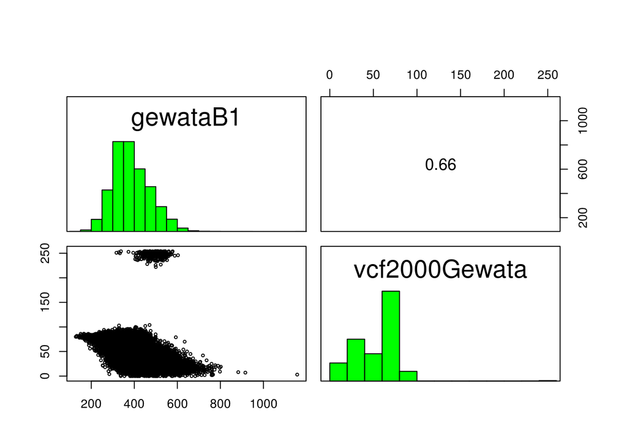

```r
#make a brick of all bands with the vcf
Gewata1 <- brick(GewataB1, vcfGewata)
Gewata2 <- brick(GewataB2, vcfGewata)
Gewata3 <- brick(GewataB3, vcfGewata)
Gewata4 <- brick(GewataB4, vcfGewata)
Gewata5 <- brick(GewataB5, vcfGewata)
Gewata6 <- brick(GewataB7, vcfGewata)

# make a scatterplot matrix
pairs(Gewata1)
```

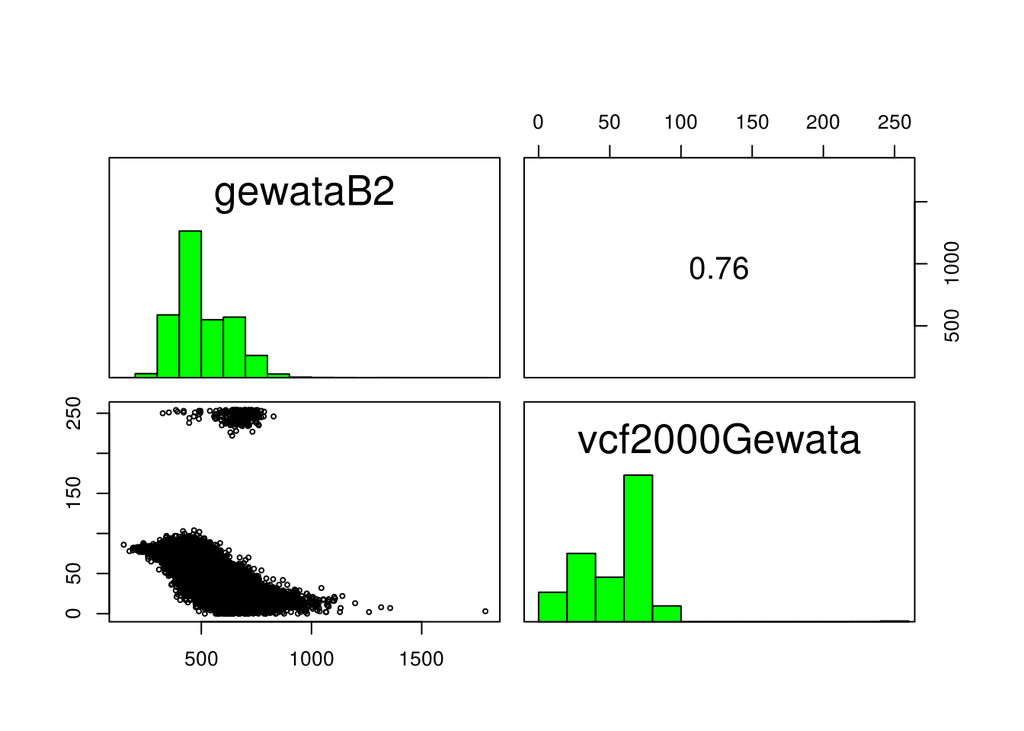

```r
pairs(Gewata2)
```

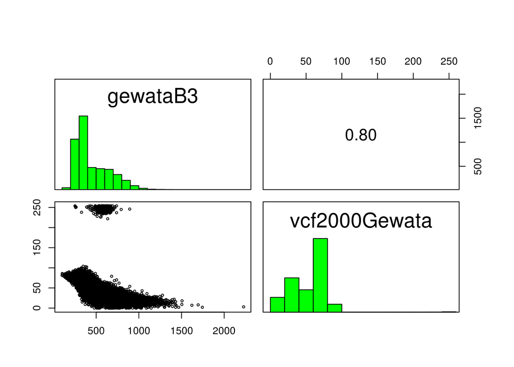

```r
pairs(Gewata3)
```

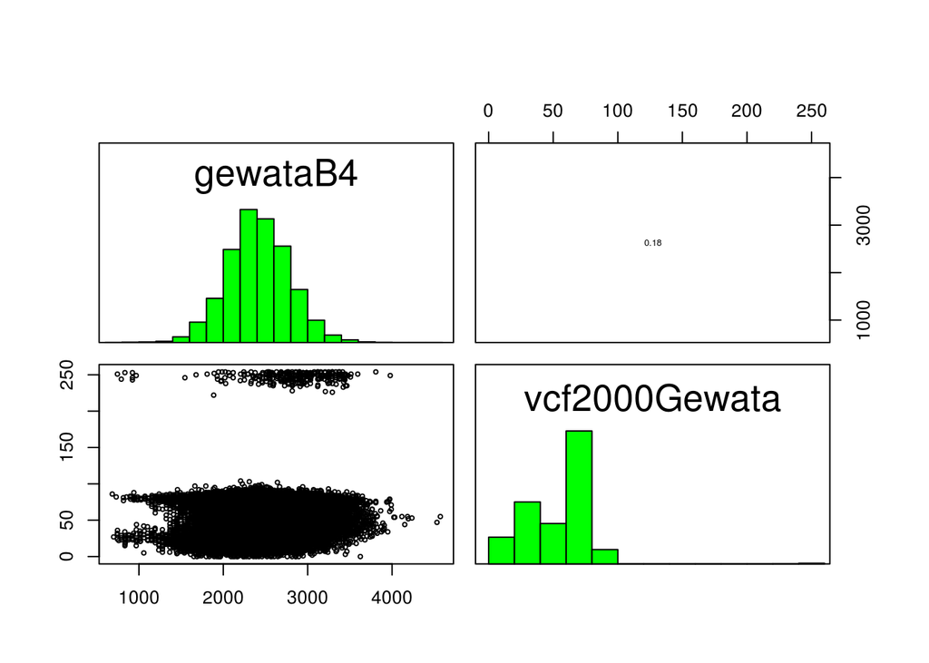

```r
pairs(Gewata4)
```

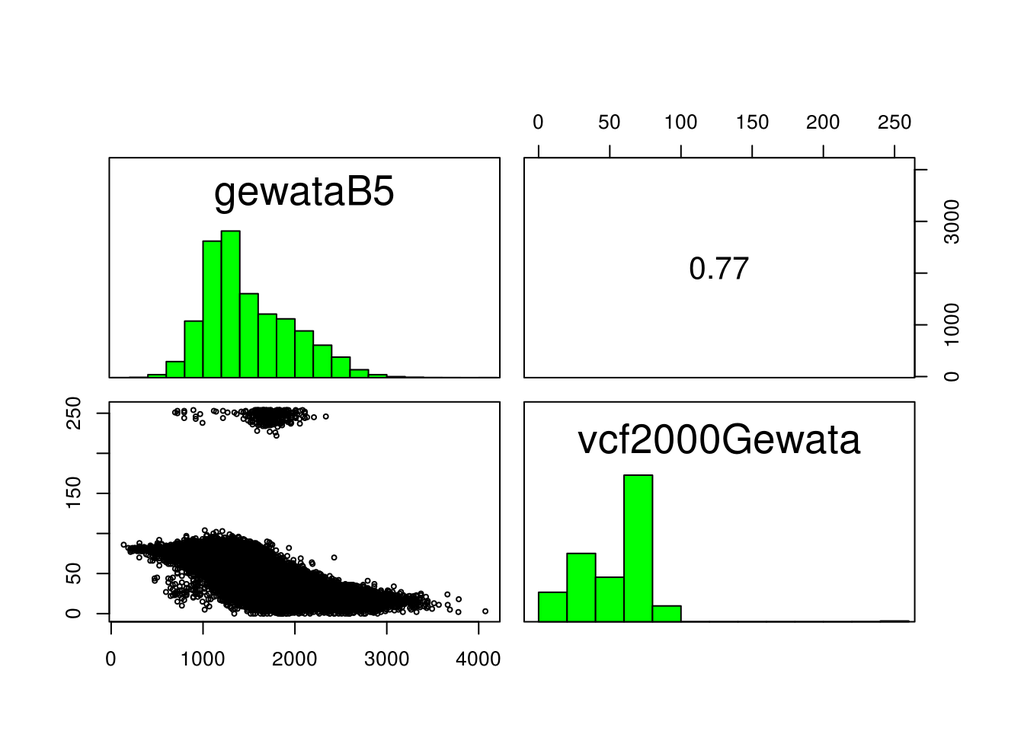

```r
pairs(Gewata5)
```

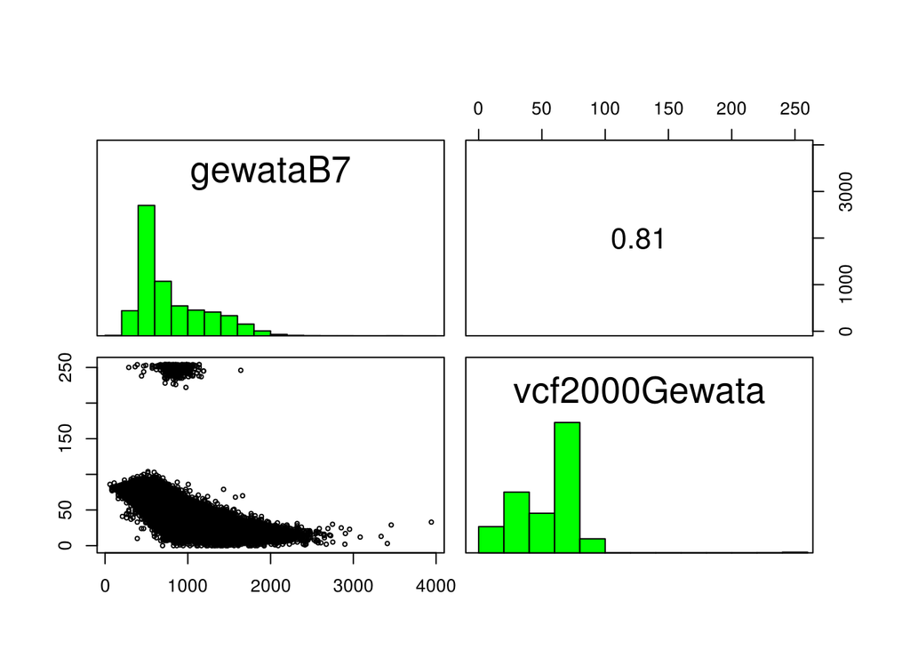

```r
pairs(Gewata6)
```

Conclusions (correlation with vcf): band1 - 0.66, band2 - 0.76, band3 - 0.80, band4 - 0.18, band5 - 0.77, band7 - 0.81. The near-infrared band(4) shows very little correlation with vcf(tree cover), therefor it is not interesting for calculating the tree cover.

2. Create an lm() model and show a summary (e.g. using summary()) of the model object you created. Which predictors (bands) are probably most important in predicting tree cover?

```r
#Remove water, cloud or cloud shadow pixels.
vcfGewata[vcfGewata > 100] <- NA

#Make a brick with all bands
gewata <- brick(GewataB1, GewataB2, GewataB3, GewataB5, GewataB7)

#Get original values
gewata <- calc(gewata, fun=function(x) x / 10000)
gewata <- addLayer(gewata, vcfGewata)

#Change names
names(gewata) <- c("band1", "band2", "band3", "band5", "band7", "vcf")

#Make data frame
valuetable <- getValues(gewata)
valuetable <- as.data.frame(valuetable)
valuetable <- na.omit(valuetable)

#Execute Regression
regression <- lm(vcf ~ band1 + band2+ band3 + band5 + band7, data=valuetable)
summary(regression)
```

```
##
## Call:
## lm(formula = vcf ~ band1 + band2 + band3 + band5 + band7, data = valuetable)
##
## Residuals:
##    Min     1Q Median     3Q    Max
## -58.07  -5.30   0.98   5.90 388.84
##
## Coefficients:
##               Estimate Std. Error t value Pr(>|t|)
## (Intercept)  1.065e+02  4.929e-02  2160.8   <2e-16 ***
## band1        7.097e+02  2.026e+00   350.2   <2e-16 ***
## band2       -1.088e+03  2.457e+00  -442.9   <2e-16 ***
## band3       -2.935e+02  1.790e+00  -164.0   <2e-16 ***
## band5        6.250e+01  5.988e-01   104.4   <2e-16 ***
## band7       -2.577e+02  8.588e-01  -300.1   <2e-16 ***
## ---
## Signif. codes:  0 '***' 0.001 '**' 0.01 '*' 0.05 '.' 0.1 ' ' 1
##
## Residual standard error: 9.412 on 1808278 degrees of freedom
## Multiple R-squared:  0.8304, Adjusted R-squared:  0.8304
## F-statistic: 1.771e+06 on 5 and 1808278 DF,  p-value: < 2.2e-16
```

(3)Plot the predicted tree cover raster and compare with the original VCF raster.

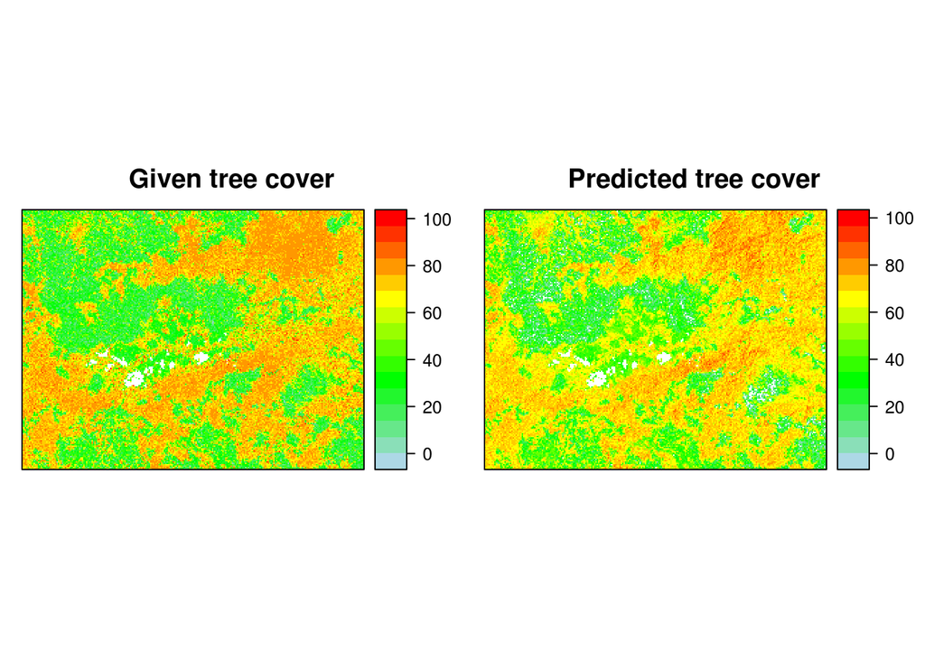

```r
#Predict tree cover
predTC <- predict(gewata, model=regression, na.rm=TRUE)
predTC[predTC<0] <- NA

#Plot both maps
p1=spplot(vcfGewata,col.regions = colorRampPalette(c("lightblue","green", "yellow","red")), main= "Given tree cover")
p2=spplot(predTC,zlim= c(0, 100),col.regions = colorRampPalette(c("lightblue","green", "yellow","red")), main= "Predicted tree cover")
print(p1, position = c(0,0,.5,1),more=T)
print(p2, position =  c(.5,0,1,1),more=T)
```

Conclusion: By comparing both plots I see little difference. This was already visible in the summary of the regression; the errors are really small for instance.

(4)Compute the RMSE between your predicted and the actual tree cover values

```r
# prepare data for RMSE
vcfGewata_new <- vcfGewata[predTC]
data_predTC <- as.data.frame(predTC)
data_predTC <- na.omit(data_predTC)
data_vcfGewata <- as.data.frame(vcfGewata_new)
data_vcfGewata <- na.omit(data_vcfGewata)

# execute RMSE
RMSE <- RMSE(data_vcfGewata,data_predTC)
print(paste("The RMSE =", RMSE))
```

```
## [1] "The RMSE = 8.99858675084453"
```

(5)Are the differences between the predicted and actual tree cover the same for all of the 3 classes we used for the random forest classfication? Using the training polygons from the random forest classification, calculate the RMSE separately for each of the classes and compare.

```r
#load and create training raster
load("AdvancedRasterAnalysis-gh-pages/data/trainingPoly.rda")
trainingPoly@data$Code <- as.numeric(trainingPoly@data$Class)
classes <- rasterize(trainingPoly, predTC, field='Code')

# calculate mean per class
zonal_predTC <- zonal(predTC, classes, mean)
zonal_vcfGewata <- zonal(vcfGewata, classes, mean)
zonal_pred_df <- as.data.frame(zonal_predTC)
zonal_vcfGewata_df <- as.data.frame(zonal_vcfGewata)
source('./R/RMSE.R')

#create RMSE per class
rmse_wetland <- RMSE(zonal_pred_df[1,2], zonal_vcfGewata_df[1,2])
rmse_forest <- RMSE(zonal_pred_df[2,2], zonal_vcfGewata_df[2,2])
rmse_cropland <- RMSE(zonal_pred_df[3,2], zonal_vcfGewata_df[3,2])
print(paste("The RMSE for wetland =", rmse_wetland))
```

```
## [1] "The RMSE for wetland = 1.29554323398984"
```

```r
print(paste("The RMSE for forest =", rmse_forest))
```

```
## [1] "The RMSE for forest = 3.71290454277643"
```

```r
print(paste("The RMSE for cropland =", rmse_cropland))
```

```
## [1] "The RMSE for cropland = 7.09279655563205"
```

Conclusion: Predicting the tree cover in cropland gives most errors, probably because it is hard to distinguish between agricultural vegetation and trees.